# Estudios de Informática, Multimedia y Telecomunicaciones

## 5.3 Respuesta ejercicio 4

### 5.3.1 Carga de datos

El dataset lo componen 289955 registros, repartidos en cuatro variables: user, artist, sex y country.

```r
df <- read.csv(file = 'lastfm.csv', header = T, sep = ',', stringsAsFactors = T)
```

Hemos cargado el fichero y comprobado el número de filas totales. Vamos a buscar relaciones entre los usuarios y los artistas o grupos que escuchan.

```r
dats <- split(x = df$artist, f = df$user)
tr.artist <- as(dats, "transactions")
(tr.artist)
```

```
## transactions in sparse format with
##  15000 transactions (rows) and
##  1004 items (columns)
```

### 5.3.2 Exploración de datos

Visualicemos las estadísticas básicas del dataset.

```r
summary(tr.artist)
```

```
## transactions as itemMatrix in sparse format with
##  15000 rows (elements/itemsets/transactions) and
##  1004 columns (items) and a density of 0.01925319
##
## most frequent items:
##             radiohead           the beatles              coldplay
##                  2704                  2668                  2378
## red hot chili peppers                  muse               (Other)
##                  1786                  1711                278706
##
## element (itemset/transaction) length distribution:
## sizes
##   1   2   3   4   5   6   7   8   9  10  11  12  13  14  15  16  17  18  19  20
## 185 222 280 302 359 385 472 461 491 501 504 482 472 471 479 477 456 455 444 455
##  21  22  23  24  25  26  27  28  29  30  31  32  33  34  35  36  37  38  39  40
## 436 478 426 438 408 446 417 375 348 340 316 293 274 286 238 208 193 181 128 102
##  41  42  43  44  45  46  47  48  49  50  51  52  54  55  63  76
##  93  61  55  36  23  15   6  11   2   1   5   3   1   2   1   1
##
##    Min. 1st Qu.  Median    Mean 3rd Qu.    Max.
##    1.00   11.00   19.00   19.33   27.00   76.00
##
## includes extended item information - examples:
##                                         labels
## 1 ...and you will know us by the trail of dead
## 2                                    [unknown]
## 3                                         2pac
##
## includes extended transaction information - examples:
##   transactionID
## 1             1
## 2             3
## 3             4
```

Podemos ahora visualizar la salida de las dos primeras transacciones.

```r
inspect(tr.artist [1:2])
```

```
##     items                     transactionID
## [1] {dropkick murphys,
##      edguy,
##      eluveitie,
##      goldfrapp,
##      guano apes,
##      jack johnson,
##      john mayer,
##      judas priest,
##      le tigre,
##      red hot chili peppers,
##      rob zombie,
##      schandmaul,
##      the black dahlia murder,
##      the killers,
##      the rolling stones,
##      the who}                             1
## [2] {aesop rock,
##      air,
##      amon tobin,
##      animal collective,
##      aphex twin,
##      arcade fire,
##      atmosphere,
##      autechre,
##      beastie boys,
##      boards of canada,
##      broken social scene,
##      cocorosie,
##      devendra banhart,
##      four tet,
##      goldfrapp,
##      joanna newsom,
##      m83,
##      massive attack,
##      max richter,
##      mf doom,
##      neutral milk hotel,
##      pavement,
##      plaid,
##      portishead,
##      prefuse 73,
##      radiohead,
##      sage francis,
##      the books,
##      the flashbulb}                       3
```

Estamos en disposición de encontrar los items más frecuentes dentro del conjunto de las transacciones.

```r
fr_items <- itemFrequency(x = tr.artist, type = "relative")
fr_items %>% sort(decreasing = TRUE) %>% head(5)
```

```
##             radiohead           the beatles              coldplay
##             0.1802667             0.1778667             0.1585333
## red hot chili peppers                  muse
##             0.1190667             0.1140667
```

Radiohead y The beatles son los que cuentan con mayor soporte, con un 18% ambos.

### 5.3.3 Aplicando Reglas de Asociación

La salida del algoritmo **"apriori**" nos indica el soporte, la confianza y el lift.

- *Soporte*: Indica el número de transacciones encontradas en la regla de {lhs} sobre el total. Mide la frecuencia.
- *Confianza*: Nos habla de la *probabilidad* de que la transacción que contiene {rhs} también encuentre los items de {lhs}. Por tanto, la confianza nos muestra la fortaleza de la regla.
- *Lift*: Nos indicará la aletoriedad en la regla. Un lift igual a 1 o cercano a 1 indica que la relación es producto del azar. Un lift>1 implica una relación fuerte, mientras que un lift<=1 nos indica una relación trivial.

Lanzamos el algoritmo *“apriori”* para generar las reglas del dataset con un mínimo de soporte del 1 % y una confianza mínima del 50 %.

```r
df_rules <- apriori(tr.artist, parameter = list(support = 0.01, confidence = 0.5, target = "rules"))
```

```
## Apriori
##
## Parameter specification:
##  confidence minval smax arem  aval originalSupport maxtime support minlen
##         0.5    0.1    1 none FALSE            TRUE       5    0.01      1
##  maxlen target  ext
##      10  rules TRUE
##
## Algorithmic control:
##  filter tree heap memopt load sort verbose
##     0.1 TRUE TRUE  FALSE TRUE    2    TRUE
##
## Absolute minimum support count: 150
##
## set item appearances ...[0 item(s)] done [0.00s].
## set transactions ...[1004 item(s), 15000 transaction(s)] done [0.13s].
## sorting and recoding items ... [655 item(s)] done [0.01s].
## creating transaction tree ... done [0.01s].
## checking subsets of size 1 2 3 4 done [0.03s].
## writing ... [50 rule(s)] done [0.00s].
## creating S4 object  ... done [0.00s].
```

Se han escrito 50 reglas. Vamos a mirar sus estadísticas.

```r
summary(df_rules)
```

```
## set of 50 rules
##
## rule length distribution (lhs + rhs):sizes
##  2  3
## 15 35
##
##    Min. 1st Qu.  Median    Mean 3rd Qu.    Max.
##     2.0     2.0     3.0     2.7     3.0     3.0
##
## summary of quality measures:
##     support          confidence        coverage            lift
##  Min.   :0.01000   Min.   :0.5013   Min.   :0.01587   Min.   : 2.781
##  1st Qu.:0.01062   1st Qu.:0.5216   1st Qu.:0.01847   1st Qu.: 3.120
##  Median :0.01147   Median :0.5430   Median :0.02150   Median : 3.283
##  Mean   :0.01296   Mean   :0.5556   Mean   :0.02359   Mean   : 3.963
##  3rd Qu.:0.01372   3rd Qu.:0.5858   3rd Qu.:0.02655   3rd Qu.: 3.711
##  Max.   :0.02927   Max.   :0.6627   Max.   :0.05747   Max.   :13.416
##      count
##  Min.   :150.0
##  1st Qu.:159.2
##  Median :172.0
##  Mean   :194.4
##  3rd Qu.:205.8
##  Max.   :439.0
##
## mining info:
##       data ntransactions support confidence
##  tr.artist         15000    0.01        0.5
```

Del set de 50 reglas, en su mayoría cuentan con 3 items (Median), con una confianza de alrededor el 55% y un lift mínimo muy por encima de 1 que nos indica que existe una fuerte relación en las reglas encontradas.

Visualizamos las reglas ordenada por confianza en orden decreciente

```r
inspect(head(sort(df_rules, decreasing = T, by='confidence')))
```

```
##     lhs                                    rhs         support    confidence
## [1] {oasis,the killers}                 => {coldplay}  0.01113333 0.6626984
## [2] {sigur rÃ³s,the beatles}            => {radiohead} 0.01046667 0.6434426
## [3] {keane}                             => {coldplay}  0.02226667 0.6374046
## [4] {radiohead,snow patrol}             => {coldplay}  0.01006667 0.6344538
## [5] {coldplay,the smashing pumpkins}    => {radiohead} 0.01093333 0.6283525
## [6] {the beatles,the smashing pumpkins} => {radiohead} 0.01146667 0.6209386
##     coverage   lift     count
## [1] 0.01680000 4.180183 167
## [2] 0.01626667 3.569393 157
## [3] 0.03493333 4.020634 334
## [4] 0.01586667 4.002021 151
## [5] 0.01740000 3.485683 164
## [6] 0.01846667 3.444556 172
```

En el cuadro anterior vemos las reglas ordenadas por la confianza. Por ejemplo, en la primera línea vemos que si un oyente escucha a Oasis y a The killer, es muy probable (66 %) que también escuche a Coldplay. Todo ello con un Lift muy bueno, superior a 1 y soportado por 167 transacciones.

Vamos a centrarnos en el grupo Coldplay encontrado y vamos a explorar que afinidad muestran los oyentes con el resto de grupos de música o artista.

```r
df_rules_search <- apriori(tr.artist, parameter = list(support = 0.01, confidence = 0.5, target = "rules"), appearance = list(rhs= c('coldplay')))
```

```
## Apriori
##
## Parameter specification:
##  confidence minval smax arem  aval originalSupport maxtime support minlen
##         0.5    0.1    1 none FALSE            TRUE       5    0.01      1
##  maxlen target  ext
##      10  rules TRUE
##
## Algorithmic control:
##  filter tree heap memopt load sort verbose
##     0.1 TRUE TRUE  FALSE TRUE    2    TRUE
##
## Absolute minimum support count: 150
##
## set item appearances ...[1 item(s)] done [0.00s].
## set transactions ...[1004 item(s), 15000 transaction(s)] done [0.17s].
## sorting and recoding items ... [655 item(s)] done [0.01s].
## creating transaction tree ... done [0.01s].
## checking subsets of size 1 2 3 4 done [0.04s].
## writing ... [16 rule(s)] done [0.00s].
## creating S4 object  ... done [0.00s].
```

Mostramos las reglas ordenada por confianza.

```r
inspect(head(sort(df_rules_search, decreasing = T, by='confidence')))
```

```
##     lhs                                  rhs        support    confidence
## [1] {oasis,the killers}               => {coldplay} 0.01113333 0.6626984
## [2] {keane}                           => {coldplay} 0.02226667 0.6374046
## [3] {radiohead,snow patrol}           => {coldplay} 0.01006667 0.6344538
## [4] {snow patrol,the killers}         => {coldplay} 0.01040000 0.5954198
## [5] {death cab for cutie,the killers} => {coldplay} 0.01086667 0.5884477
## [6] {oasis,radiohead}                 => {coldplay} 0.01273333 0.5876923
##     coverage   lift     count
## [1] 0.01680000 4.180183 167
## [2] 0.03493333 4.020634 334
## [3] 0.01586667 4.002021 151
## [4] 0.01746667 3.755802 156
## [5] 0.01846667 3.711823 163
## [6] 0.02166667 3.707058 191
```

Hemos afinado más la búsqueda mostrando que las reglas de asociación entre los principales artistas o grupos y su afinidad con el grupo Coldplay.

# 6 Ejercicio 5

## 6.1 Enunciado

Busca información sobre otros métodos de agregación diferentes al *k-means*. Partiendo del Ejercicio 3, probar el funcionamiento de al menos 2 métodos diferentes y comparar los resultados obtenidos.

## 6.2 Respuesta ejercicio 5

### 6.2.1 Agrupamiento jerárquico

El método del agrupamiento jerárquico se basa en construir una jerarquía de grupos, basado en la **semejanza de los datos**. Utilizando el concepto de distancia entre los puntos, se calcula los puntos que se encuentra más cercanos entre ellos, por pares. El siguiente paso es es ir *agregando* nuevos grupos por cercanía. Para visualizar el funcionamiento de la clusterización, se suele utilizar el **dendograma.** En este diagrama, cada clase es visualizada por una línea vertical y la selección del número de clases idóneas es estimada a partir del diagrama.

Los métodos llamados `Hierarchical Clustering`, y tienen la ventaja de que no requieren conocer de antemano el número de clústers a utilizar y, además utilizan solamente la matriz de distancia, por lo que son independientes de las observaciones.

Como parámetros críticos de configuración encontramos la función utilizada para el cálculo de la distancia, y el método de agrupamiento.

A continuación podemos ver el dendograma del dataset normalizado del Ejercicio 3, utilizando la **distáncia euclidiana** y como método de agregación **el criterio de Ward**, basado en el decrecimiento de la varianza entre los grupos que van siendo mezclados.

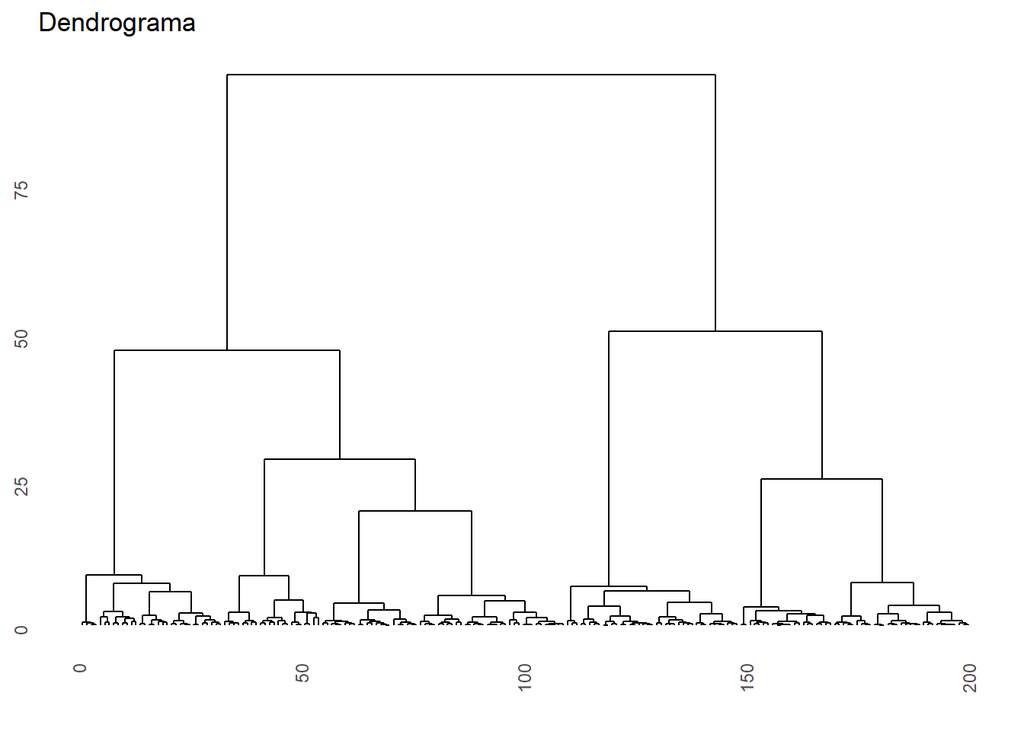

```r
library(ggdendro)
dendrogram <- hclust(dist(df.scale, method = 'euclidean'), method = 'ward.D')
ggdendrogram(dendrogram, rotate = FALSE, labels = FALSE, theme_dendro = TRUE) +
  labs(title = "Dendrograma")
```

Fijándonos en el dendograma, encontramos las primeras agrupaciones formadas por los número de clases 2, 4, 5 y 6.

```r
k <- c(2,4,5,6)
agrupamientoJ <- hclust(dist(df.scale, method = 'euclidean'), method = 'ward.D')
for (i in k){
  clases_aj <- cutree(agrupamientoJ, k = i)
  df.scale[, paste0('cluster.', i)] <- clases_aj
}
```

Una vez generado los cluster, vamos a verlos representados

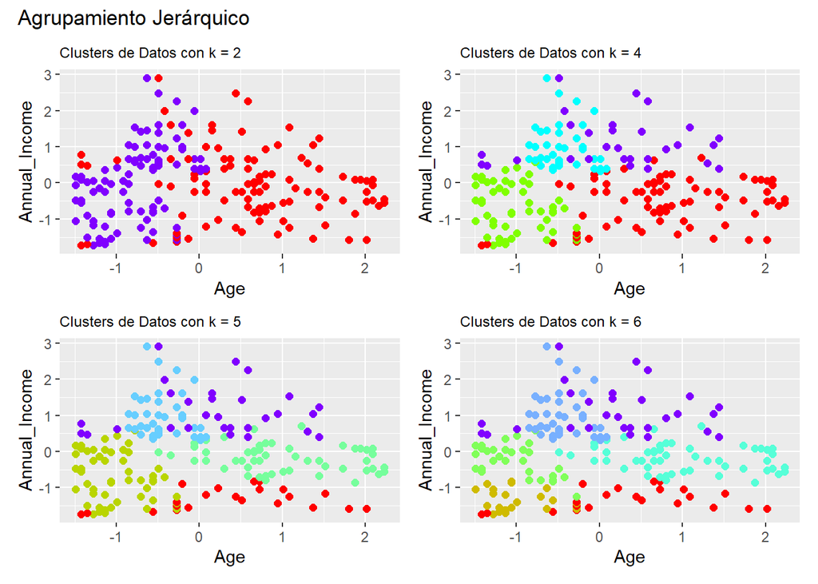

```r
library(patchwork)
p2 <- ggplot() + geom_point(aes(x = Age, y = Annual_Income_.k.., color = cluster.2), data = df.scale, size = 2, show.legend = F) +
  scale_colour_gradientn(colours=rainbow(4)) +
  ggtitle('Clusters de Datos con k = 2') +
  theme(plot.title = element_text(size=9)) +
  xlab('Age') + ylab('Annual_Income')

p4 <- ggplot() + geom_point(aes(x = Age, y = Annual_Income_.k.., color = cluster.4), data = df.scale, size = 2, show.legend = F) +
  scale_colour_gradientn(colours=rainbow(4)) +
  ggtitle('Clusters de Datos con k = 4') +
  theme(plot.title = element_text(size=9)) +
  xlab('Age') + ylab('Annual_Income')
p5 <- ggplot() + geom_point(aes(x = Age, y = Annual_Income_.k.., color = cluster.5), data = df.scale, size = 2, show.legend = F) +
  scale_colour_gradientn(colours=rainbow(4)) +
  theme(plot.title = element_text(size=9)) +
  ggtitle('Clusters de Datos con k = 5') +
  xlab('Age') + ylab('Annual_Income')

p6 <- ggplot() + geom_point(aes(x = Age, y = Annual_Income_.k.., color = cluster.6), data = df.scale, size = 2, show.legend = F) +
  scale_colour_gradientn(colours=rainbow(4)) +
  theme(plot.title = element_text(size=9)) +
  ggtitle('Clusters de Datos con k = 6') +
  xlab('Age') + ylab('Annual_Income')

(p2 | p4 ) / (p5 | p6) +  plot_annotation(title = 'Agrupamiento Jerárquico')
```

Aunque con una separación de dos grupos no se llega a obtenerse una separación perfecta entre los grupos, no vemos mejora al aumentar el numero de clústeres.

**Referencias Externas**:

- https://rpubs.com/rdelgado/399475

- https://es.wikipedia.org/wiki/Agrupamiento_jer%C3%A1rquico

### 6.2.2 Clusterización mediante K-menoids (PAM)

Es un método de agrupación muy similar al K-means, pero mientras que en éste, el centroide constituye el elemento central del clúster, en K-menoids cada clúster se encuentra representado por una observación, el **menoid**, elemento del clúster cuya distancia promedio entre él y el resto de los elementos que integran la agrupación es mínima, y que constituye el elemento central.

Con respecto a K-means, es un algoritmo más robusto y que se ve menos influenciado por el ruido presente en la serie. Como desventaja, encontramos que necesita de muchos recursos computacionales, por lo que en está desaconsejado en el caso de datasets grandes.

Vamos a evaluar la reducción de la varianza para un valor máximo de k de 10. Al no apreciarse outliers en el dataset, utilizamos la distancia euclidea. Como estimador utilizamos la reducción de la suma total de los cuadrados de las diferencias internas.

```r
library(cluster)
library(factoextra)
```

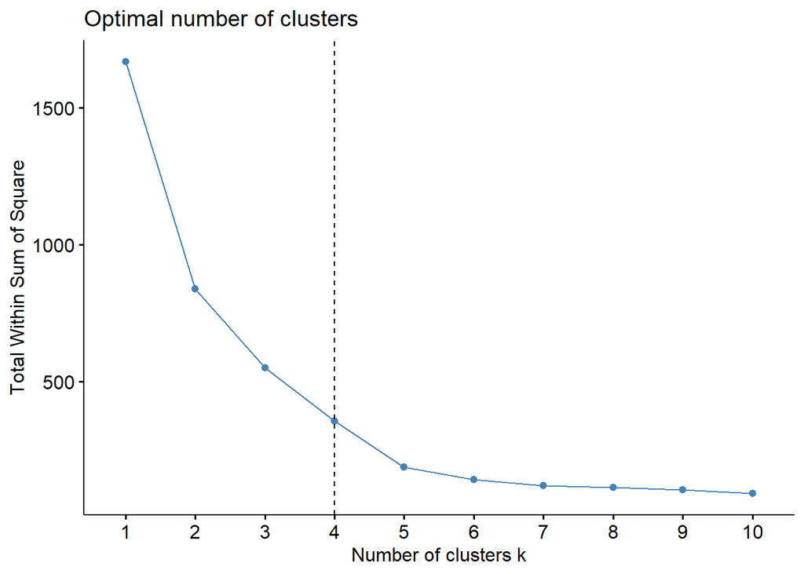

```r
fviz_nbclust(x = df.scale, FUNcluster = pam, method = "wss", k.max = 10,
             diss = dist(df.scale, method = "euclidean")) +
geom_vline(xintercept = 4, linetype = 2)
```

Se aprecia que el mejor valor encontrado corresponde para un valor de k de 4, que es en donde la curva parece que comienza a suavizar su pendiente.

Vamos a probar también con “**silhouette**” como estimador, tal y como hicimos con el método k-means del ejercicio 3.

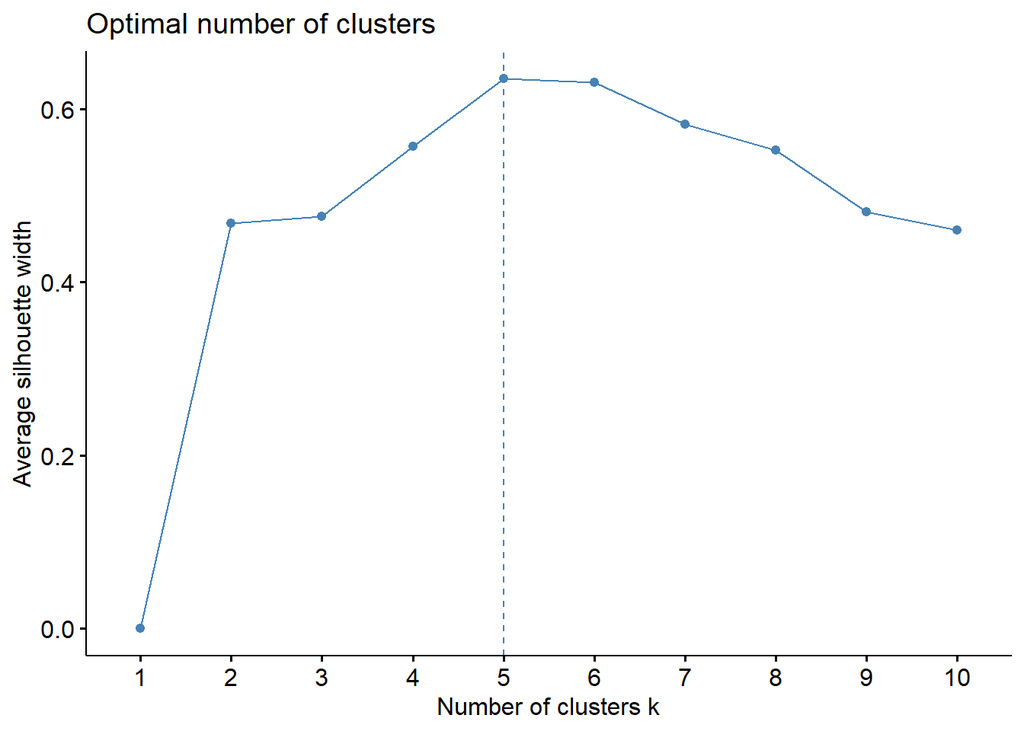

```r
fviz_nbclust(x = df.scale, FUNcluster = pam, method = "silhouette", k.max = 10,
             diss = dist(df.scale, method = "euclidean"))
```

```r
set.seed(1234)

pam_clusters.k4 <- pam(x=df.scale, k= 4, metric = "euclidean")
pam_clusters.k6 <- pam(x=df.scale, k= 6, metric = "euclidean")
```

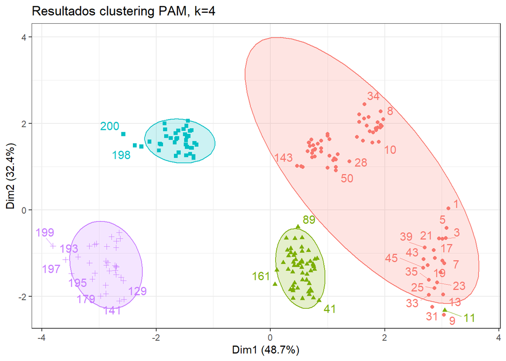

```r
fviz_cluster(object = pam_clusters.k4, data = df.scale, ellipse.type = "t",
             repel = TRUE) +
  theme_bw() +
  labs(title = "Resultados clustering PAM, k=4") +
  theme(legend.position = "none")
```

El dataset queda muy bien catalogado en cuatro grupos. Vamos a visualizar lo que se obtiene con 6 clusteres.

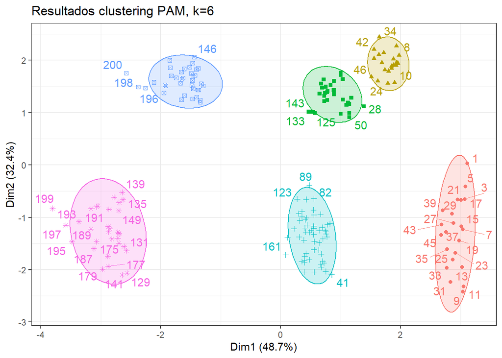

```r
fviz_cluster(object = pam_clusters.k6, data = df.scale, ellipse.type = "t",
             repel = TRUE) +
  theme_bw() +
  labs(title = "Resultados clustering PAM, k=6") +
  theme(legend.position = "none")
```

Parece que con éste número de agrupaciones se ha conseguido una mejor diferenciación entre los elementos que componen los grupos, sobretodo en el centro.

### 6.2.3 Clusterización mediante CLARA

Hemos visto que una de las debilidades de K-menoids se encuentra en el consumo de recursos. El algoritmo de CLARA (*Clustering Large Applications*) combina el concepto de **K-menoids** con el **resampling**, utilizando muestras aleatorias de un tamaño definido y aplicando el algoritmo de PAM (K-menoids). Este funcionamiento permite que sea un algoritmo útil para que pueda usar en largos datasets.

Lanzamos el dataset según los valores de k encontrados anteriormente, 4 y 6.

```r
set.seed(1234)

clara_clusters.k4 <- clara(x = df.scale, k = 4, metric = "euclidean", stand = F,
                        samples = 50, pamLike = TRUE)
clara_clusters.k6 <- clara(x = df.scale, k = 6, metric = "euclidean", stand = F,
                        samples = 50, pamLike = TRUE)
```

Como realizamos anteriormente, vamos a visualizar los resultados para cuatro agrupaciones

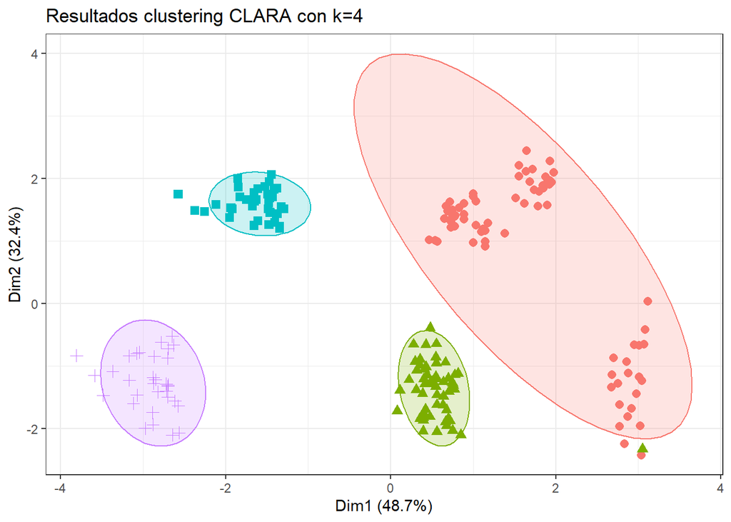

```r
fviz_cluster(object = clara_clusters.k4, ellipse.type = "t", geom = "point",
             pointsize = 2.5) +
  theme_bw() +
  labs(title = "Resultados clustering CLARA con k=4") +
  theme(legend.position = "none")
```

Vemos un resultado muy parecido al obtenido con k-menoids, lógico si sabemos que se basa en el mismo concepto.

Probemos con el siguiente valor de agrupaciones.

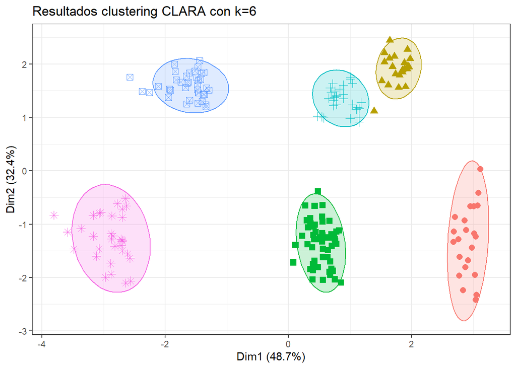

```r
fviz_cluster(object = clara_clusters.k6, ellipse.type = "t", geom = "point",
             pointsize = 2.5) +
  theme_bw() +
  labs(title = "Resultados clustering CLARA con k=6") +
  theme(legend.position = "none")
```

### 6.2.4 Clusterización mediante DBSCAN

La idea detrás del algoritmo de cluesterización “**`Density based clustering`**” (DBSCAN), está en realizar las agrupaciones por regiones, según la densidad de las observaciones.

A diferencia del resto de algoritmos de particionado que fallan al identificar formas arbitrarias, **DBSCAN** agrupa las observaciones en el cluster partiendo del principio de que tiene que haber un mínimo de obervaciones vecinas dentro de un radio próximo y de que los clústeres han de estar separados por regiones vacías o con pocas observaciones.

Como **ventajas** del algoritmo DBSCAN, tenemos que al contrario que los algoritmos vistos hasta ahora, no se requiere conocer el número de clusters. Además, es independiente de la forma, no estando obligado a que sigan una forma redonda alrededor de un punto como K-means o K-menoids. Ésto permite identificar a los outliers, por lo que es una algoritmo recomendado en datasets con ruído.

El algoritmo necesita los siguientes parámetros de entrada:

- **Epsilon** (ϵ): radio que define la región vecina a una observación, también llamada ϵ-neighborhood.
- **Minimum points** (minPts): El mínimo número de observaciones dentro de la región epsilon. Cuanto mayor sea el tamaño del dataset, más grande ha de ser este valor, no bajando nunca de 3.

Vamos a encontrar el valor más óptimo para epsilon, utilizando 5 para minPts (se ha probado con diferentes valores entre 2 y 10, no encontrando diferencia aparente).

```r
set.seed(1234)
library(fpc)
library(dbscan)
```

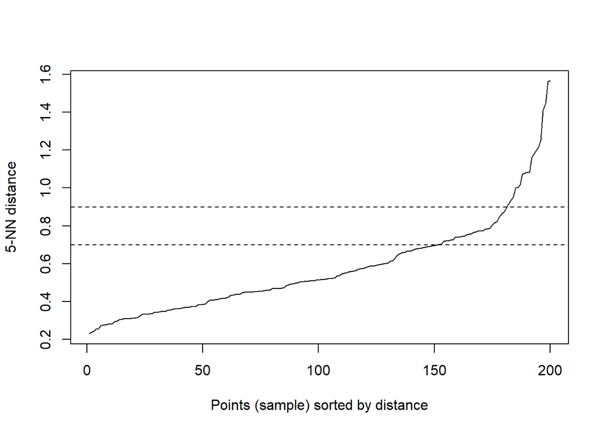

```r
minpts <- 5
kNNdistplot(df.scale, k = minpts)
abline(h = 0.9, lty = 2)
abline(h = 0.7, lty = 2)
```

No queda muy claro que valor de épsilon escoger. Estaría entre 0.7 y 0.9, por lo que vamos a probar con diferentes valores y ver el resultado.

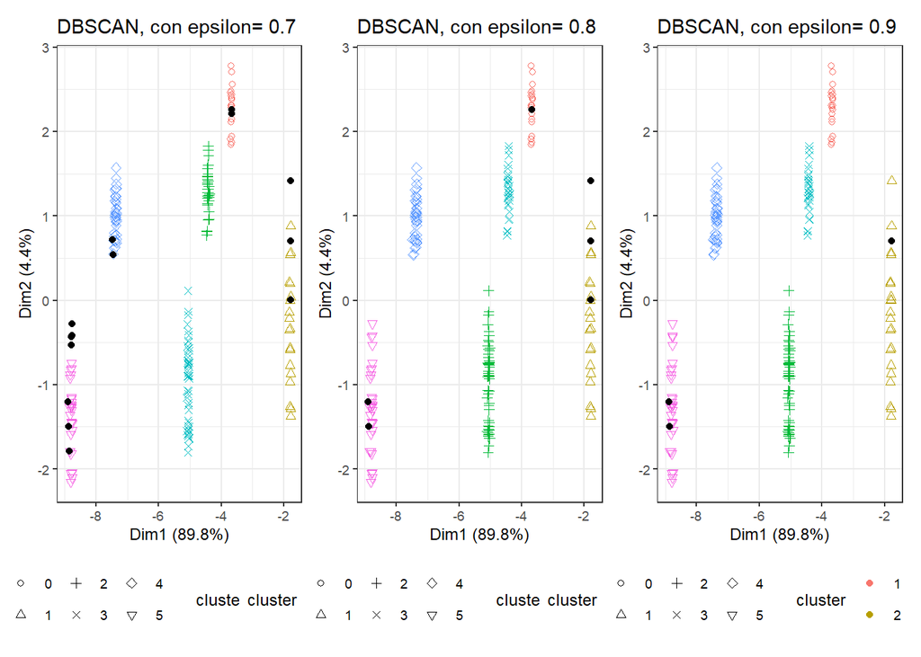

```r
e <- c(0.7, 0.8, 0.9)
dbscan_cluster.e1 <- fpc::dbscan(data = df.scale, eps = e[1], MinPts = minpts)
dbscan_cluster.e2 <- fpc::dbscan(data = df.scale, eps = e[2], MinPts = minpts)
dbscan_cluster.e3 <- fpc::dbscan(data = df.scale, eps = e[3], MinPts = minpts)

p1 <- fviz_cluster(object = dbscan_cluster.e1, data = df.scale, stand = FALSE,
             geom = "point", ellipse = FALSE, show.clust.cent = FALSE,
             pallete = "jco") +
  labs(title = paste0("DBSCAN, con epsilon= ",e[1])) +
  theme_bw(base_size = 9) +
  theme(legend.position = "bottom")

p2 <- fviz_cluster(object = dbscan_cluster.e2, data = df.scale, stand = FALSE,
             geom = "point", ellipse = FALSE, show.clust.cent = FALSE,
             pallete = "jco") +
  labs(title = paste0("DBSCAN, con epsilon= ",e[2])) +
  theme_bw(base_size = 9) +
  theme(legend.position = "bottom")

p3 <- fviz_cluster(object = dbscan_cluster.e3, data = df.scale, stand = FALSE,
             geom = "point", ellipse = FALSE, show.clust.cent = FALSE,
             pallete = "jco") +
  labs(title = paste0("DBSCAN, con epsilon= ",e[3])) +
  theme_bw(base_size = 9) +
  theme(legend.position = "bottom")


p1 + p2 + p3
```

Ya vemos la diferencia visual con respecto al resto de algoritmos vistos hasta el momento. Pero para saber cual de los tres ha dado mejor resultado, miraremos sus números.

```r
print.dbscan(dbscan_cluster.e1)
```

```
## dbscan Pts=200 MinPts=5 eps=0.7
##         0  1  2  3  4  5  6
## border 14  0  8  2  3  2  6
## seed    0 19 11 29 52 35 19
## total  14 19 19 31 55 37 25
```

```r
print.dbscan(dbscan_cluster.e2)
```

```
## dbscan Pts=200 MinPts=5 eps=0.8
##        0  1  2  3  4  5  6
## border 6  1  4  0  1  2  7
## seed   0 19 15 55 30 37 23
## total  6 20 19 55 31 39 30
```

```r
print.dbscan(dbscan_cluster.e3)
```

```
## dbscan Pts=200 MinPts=5 eps=0.9
##        0  1  2  3  4  5  6
## border 3  2  4  0  1  2  5
## seed   0 19 17 55 30 37 25
## total  3 21 21 55 31 39 30
```

El número de columna corresponde al número del clúster. DBScan reserva el valor 0 para los outliers (en negro).

Conforme se disminuye el valor de épsilon, al algoritmo le cuesta más diferenciar los clústeres, siendo el valor de 0,9 el que obtiene un diferenciación más alta entre los grupos de puntos, dejando fuera a sólo 3 observaciones sin grupo. Jugando con el valor de épsilon, podríamos afinar más el algoritmo hasta conseguir que todas las observaciones queden agrupadas.

**Referencia externa**: https://www.cienciadedatos.net/documentos/37_clustering_y_heatmaps#Introducci%C3%B3n

# 7 Criterios de evaluación

## 7.1 Ejercicio 1 (20%)

- 60%. Explicar de forma resumida cual es el objetivo de los métodos de agregación. Relacionar la respuesta con un ejemplo.
- 40%. Razonar si tiene sentido aplicar un método agregación al ejemplo que pusiste en la PEC1. Si lo tiene, comentar como se podría aplicar y que tipo de resultados se podrían obtener. Si no lo tiene, reformular el problema para que si lo tenga.

## 7.2 Ejercicio 2 (20%)

- 60%. Explicar de forma resumida cual es el objetivo de los métodos de generación de reglas de asociación. Relacionar la respuesta con un ejemplo.
- 40%. Razonar si tiene sentido aplicar un método de generación de reglas de asociación al ejemplo que pusiste en la PEC1. Si lo tiene, comentar como se podría aplicar y que tipo de resultados se podrían obtener. Si no lo tiene, reformular el problema para que si lo tenga.

## 7.3 Ejercicio 3 (25%)

- 20%. Se explican los campos de la base de datos, preparación y análisis de datos
- 20%. Se aplica el algoritmo de agrupamiento de forma correcta y se prueban con diferentes valores de k.
- 10%. Se obtiene una medida de lo bueno que es el agrupamiento.
- 40%. Se ponen nombres a las asociaciones y se describen e interpretan los diferentes clústers obtenidos.
- 10%. Se presenta el código y es fácilmente reproducible.

## 7.4 Ejercicio 4 (25%)

- 10%. Se realiza un resumen de los datos incluidos en la base de datos.
- 15%. Se preparan los datos de forma correcta.
- 10%. Se aplica el algoritmo de reglas de asociación.
- 20%. Se realizan diferentes pruebas variando algunos parámetros.
- 35%. Se explican las conclusiones que se obtienen.
- 10%. Se presenta el código y es fácilmente reproducible.

## 7.5 Ejercicio 5 (10%)

- 25%. Se prueba un algoritmo diferente al kmeans.
- 25%. Se prueba otro algoritmo diferente al kmeans.
- 40%. Se comparan los resultados del kmeans y los otros dos métodos probados en este ejercicio.
- 10%. Se presenta el código y es fácilmente reproducible.